# Immunity Calculation 2.0

Alexander Upfill-Brown

2014-12-02

### Introduction

This page discusses work devoted to improving our calculation of population immunity based on NP-AFP data. The goal is to develop an algorithm that uses NP-AFP data for a locality and enables easier projections and testing of hypothetical immunization campaign calendars.

This algorithm should have the follow properties:

1. **Responsiveness** - population immunity should respond immediately following a campaign.
2. **Aplicability to small area estimates** - one of the advantages of our current smoothing approach is that we are able to estimate immunity at the district-level and relate this to cases.
3. **Easy to manipulate** - inputs should be explicit so that hypothetical populations, accessibility structures, and campaign calendars can be readily evaluated.

### Immunity Calculation 1.0

Currently, our best approach allows immunity calculation in six-month periods. The process is summarized below:

1. For each NP-AFP case aged 6-59 months, make onset date equal to the end date of the six-month period they reported AFP, then adjust birth date so that age is unchanged.
2. Estimate the campaign exposure based on campaigns occuring in district of onset within adjusted birth and onset dates.
3. Estimate the individual probability of protection using reported OPV doses, campaign exposure, and dose efficacies (described [here](http://amupfill.github.io/IPV_Immunity_Calculation/#immunity-calulcation-function)).
4. Use a Bayesian heirarchical temporal model (see below), we estimate ‘smoothed’ district level immunity. This step is important as it reduces noise arising from the small NP-AFP sample size at the district-level. $\begin{align} I_{ijt} &\sim \text{N}\left(X_{ijt}, \frac{\sigma^{2}}{n_{ijt}}\right)\\ X_{ijt} &= \alpha + P_{1i} + P_{1it} + D_{1ij} + D_{1ijt} \end{align}$ Where $X_{ijt}$ is the immunity estimate in district $j$ in province $i$ in time period $t$. $I_{ijt}$ is the unadusted immunity estimate from that period and $n_{ijt}$ is the number of NP-AFP cases on which that estimate is based.

This approach meets criterion **1** and **2** in the list in the introduction, it fails miserably with regard to property **3**. In this approach, campaign coverage & accessibility are not modeled explicitly and so therefore cannot be adjusted easily. The hope is that version 2.0 will make the different underlying concepts of the immunity calculation easy to observe and manipulate.

### A Path(s) Forward

All immunity alrogithms will require modeled estimates of campaign coverage from NP-AFP (there are other data sources for campaign coverage–LQAS, IM–but NP-AFP is the most universal dataset) in some form or another.

#### Option 1

Hil has previously a method for infering campaign coverage in two accessibility groups from NP-AFP, and then combining this with the historical campaign calendar to reconstruct immunity in a location. Campaign coverage was estimated for campaigns occuring within a given year. Therefore, a five year-old would have experienced campaigns at 5 different coverage levels. This would have to be taken into account when reconstructing immunity.

As of now, this method does not account for differences by age nor does it currently extend to small spatial scales. That being said, following estimation of relevant paramaters from AFP data, this approach does meet criteria **1** and **3** above.

#### Option 2 - Heirachical Coverage Modeling

I have previously used a heirachical Bayesian binomial model to estimate coverage by district, time-point, and age group. This coverage was not campaign specific. Instead, for a given time period, it represented the average lifetime coverage of a child in a certain age group with a date of onset in that period.

While this method incorporates district-level heterogeneity, and the coverage outputs are easily manipulated in theory, this method does not account for accesibility. Combine the coverage outputs from this model with the campaign calendar to estimate responsive immunity estimates.

### Heirachical Coverage Model

Below is the WinBUGS model used for **Option 2** above. This model is used to estimate the age stratified coverage for districts in a given state, for example Kano.

```
## function(){
##   # Model
##   for(i in 1:N){
##     doses[i] ~ dpois(mu[i])
##     mu[i] <- cov[i]*campaigns[i]
##     logit(cov[i]) <- beta0 + beta1[period[i]] + beta2[cluster[i]] + beta3[age_group[i]]
##   }
##
##   for(n in 1:n.period){
##     for(l in 1:n.cluster){
##       logit(mean.cov0[n,l]) <- beta0 + beta1[n] + beta2[l] + beta3[1]
##       logit(mean.cov1[n,l]) <- beta0 + beta1[n] + beta2[l] + beta3[2] # + beta2*0.5
##       logit(mean.cov2[n,l]) <- beta0 + beta1[n] + beta2[l] + beta3[3] ## + beta2*0.5
##       logit(mean.cov3[n,l]) <- beta0 + beta1[n] + beta2[l] + beta3[4] ## + beta2*0.5
##       logit(mean.cov4[n,l]) <- beta0 + beta1[n] + beta2[l] + beta3[5] ## + beta2*0.5
##     }
##   }
##
##   # Priors
##   beta0 ~ dnorm(0,1E-5)
##   beta1[1:n.period] ~ car.normal(adj.t[], weights.t[], num.t[], tau.beta1)
##   for(c in 1:n.cluster){
##     beta2[c] ~ dnorm(0, tau.beta2)
##   }
##   for(a in 1:5){
##     beta3[a] ~ dnorm(0,1E-5)
##   }
##   tau.beta1 ~ dgamma(0.01,0.01)
##   tau.beta2 ~ dgamma(0.01,0.01)
## }
```

Using the fitted age stratified coverages, we can reconstruct a hypothetical population and population immunity with the historical campaign calendar. The associated function for this analysis are below.

### Immunity Reconstruction Functions

```r
### Generate initial age-based dose distribution - this and the below function need to be integrated better
generateInitialDoses = function(starting.year=2004, dist.index, coverage.results, campaigns, random=F){
  campaigns.lim = campaigns[campaigns$start_date < as.Date(paste0(starting.year,"-01-01")) & campaigns$index==dist.index,]
  coverage.use = coverage.results[coverage.results$year == starting.year & coverage.results$index==dist.index,]
  initial.doses = data.frame(age_tranch=seq(0,4.5,.5), topv=0,bopv=0,mopv1=0,mopv3=0,ipv=0)
  initial.doses$birth_date = as.Date(paste0(starting.year,"-01-01")) - round((initial.doses$age_tranch + .25)*364.75)
  initial.doses$exposure = sapply(initial.doses$birth_date, function(x) length(which(campaigns.lim$start_date > x)))
  if(random) initial.doses$topv = rbinom.vec(1, initial.doses$exposure,coverage.use$coverage_pred[match(trunc(initial.doses$age_tranch),coverage.use$age_group)])
  if(!random) initial.doses$topv = round(initial.doses$exposure*coverage.use$coverage_pred[match(trunc(initial.doses$age_tranch),coverage.use$age_group)])
  return(initial.doses[,c("age_tranch","topv","bopv","mopv1","mopv3","ipv")])
}

### Create AFP dataset given initials
createAFPData = function(starting.year=2004, n=200, initial.doses, dist.index){
  # initial.doses is a data.frame with column "age_tranch" and "doses
  onset.date=as.Date(paste0(starting.year,"-01-01"))
  birth.date=seq(as.Date(paste0(starting.year-5,"-01-10")),onset.date-1, length.out=n)
  age = as.numeric(onset.date - birth.date)/364.75
  age_tranch = cut(age, seq(0,5,.5), labels=seq(0,4.5,.5))
  #return(data.frame(index=dist.index, id=1:n, onset.date=onset.date, birth.date = birth.date, age=age, age_tranch=age_tranch, doses = initial.doses$doses[match(age_tranch,initial.doses$age_tranch)]))
  return(data.frame(index=dist.index, id=1:n, onset.date=onset.date, birth.date = birth.date, age=age, age_tranch=age_tranch, initial.doses[match(age_tranch,initial.doses$age_tranch),c("topv","bopv","mopv1","mopv3","ipv")]))
}

rbinom.vec = Vectorize(rbinom)

### Immunity Calculation function
calcImmunity_ipv = function(tOPV, bOPV, mOPV1, mOPV3, IPV=0, type=1, region, opvExperienced=F){
  doses = tOPV+bOPV+mOPV1+mOPV3+IPV
  if(is.na(doses)) return(NA)
  if(!opvExperienced){
    if(region=="north") eff = eff.north
    if(region=="south") eff = eff.south
    eff[,5] = c(ipv.niave.t1,ipv.niave.t2,ipv.niave.t3)
  } else {
    if(region=="north") eff = eff.north
    if(region=="south") eff = eff.south
    eff[,5] = c(ipv.opvback.t1,ipv.opvback.t2,ipv.opvback.t3)
  }
  return(1 - ((1-eff[type,1])^(tOPV+IPV) * (1-eff[type,4])^bOPV*(1-eff[type,2])^mOPV1 * (1-eff[type,3])^mOPV3 * (1-eff[type,5])^IPV))
}
calcImmunity.vec = Vectorize(calcImmunity_ipv)

simulateCampaigns = function(campaigns=camps, coverage.results=cov.results, data, time.step=1, immunity.age.range=c(0.5,3), serotype){
  onset.old = data$onset.date[1]
  data$onset.date = data$onset.date + time.step
  ages.new = as.numeric(data$onset.date - data$birth.date)/364.75
  # Replace children over five
  if(sum(ages.new>=5)){
    inds = which(ages.new>=5)
    data$birth.date[inds] = data$onset.date[1] - 1
    data[inds,c("topv","bopv","mopv1","mopv3","ipv")] = rep(0,5)
    data$id = max(data$id) + 1
  }
  data$age = as.numeric(data$onset.date - data$birth.date)/364.75
  data$age_tranch = as.numeric(as.character(cut(data$age, seq(0,5,.5), labels=seq(0,4.5,.5))))
  # Adjust doses if campaign
  if(sum(campaigns$start_date > onset.old & campaigns$start_date <= data$onset.date[1])>0){
    inds = which(campaigns$start_date > onset.old & campaigns$start_date <= data$onset.date[1])
    for(c in 1:length(c)){
      year = as.numeric(format(campaigns$start_date[inds[c]],"%Y"))
      vaccine = tolower(campaigns$vaccinetype[inds[c]])
      age_group = trunc(data$age_tranch)
      coverage.results = coverage.results[coverage.results$year==year & coverage.results$index==data$index[1],]
      coverages = coverage.results$coverage_pred[match(age_group,coverage.results$age_group)]
      data[,vaccine] = data[,vaccine] + rbinom.vec(1, 1, coverages)
    }
  }
  # Estimate Immunity
  doses = data[data$age > immunity.age.range[1] & data$age < immunity.age.range[2],c("topv","bopv","mopv1","mopv3","ipv")]
  immunity = calcImmunity.vec(tOPV=doses$topv+doses$ipv, bOPV=doses$bopv, mOPV1=doses$mopv1, mOPV3=doses$mopv3, type=serotype, region="north")
  # Return data, and immunity
  return(list(data=data,immunity=immunity))
}

st.err <- function(x) sd(x)/sqrt(length(x))

### Simulate immunization over time
simulateImmunization = function(start.year=2004, end.date=as.Date("2014-09-01"), time.step=10, quantile.immunity=F,
                                campaigns, cov.results, n.samples=200, initial.doses=NA, dist.index,
                                immunity.age.range=c(0.5,3), serotype=1, generate.initials=T, initials.random=F){
  # Creat data
  campaigns = campaigns[campaigns$index==dist.index,]
  if(generate.initials) initial.doses = generateInitialDoses(start.year, dist.index, cov.results, campaigns, random=initials.random)
  data = createAFPData(start.year, n.samples, initial.doses, dist.index)

  output = simulateCampaigns(campaigns, cov.results, data, time.step, immunity.age.range=immunity.age.range, serotype=serotype)
  onset.date = output$data$onset.date[1]
  if(!quantile.immunity){
    mean.im = mean(output$immunity)
    immunity.output = data.frame(date = onset.date, mean=mean.im,
                                 lower_ci=mean.im-1.96*st.err(output$immunity),
                                 upper_ci=mean.im+1.96*st.err(output$immunity))
  } else {
    quant.im = c(mean(output$immunity)-sd(output$immunity), mean(output$immunity),mean(output$immunity)+sd(output$immunity))
    immunity.output = data.frame(date = onset.date, mean=quant.im[2], lower_ci=quant.im[1], upper_ci=quant.im[3])
  }

  while(onset.date < end.date){
    output = simulateCampaigns(campaigns, cov.results, output$data, time.step, immunity.age.range=immunity.age.range, serotype=serotype)
    (onset.date = output$data$onset.date[1])
    if(!quantile.immunity){
      mean.im = mean(output$immunity)
      immunity.output = rbind(immunity.output, data.frame(date = onset.date, mean=mean.im,
                                   lower_ci=mean.im-1.96*st.err(output$immunity),
                                   upper_ci=mean.im+1.96*st.err(output$immunity)))
    } else {
      quant.im = c(mean(output$immunity)-sd(output$immunity), mean(output$immunity),mean(output$immunity)+sd(output$immunity))
      immunity.output = rbind(immunity.output, data.frame(date = onset.date, mean=quant.im[2], lower_ci=quant.im[1], upper_ci=quant.im[3]))
    }
  }

  return(immunity.output)
}
```

### Kano Immunity Reconstruction Example

These can all be combined to produce the following:

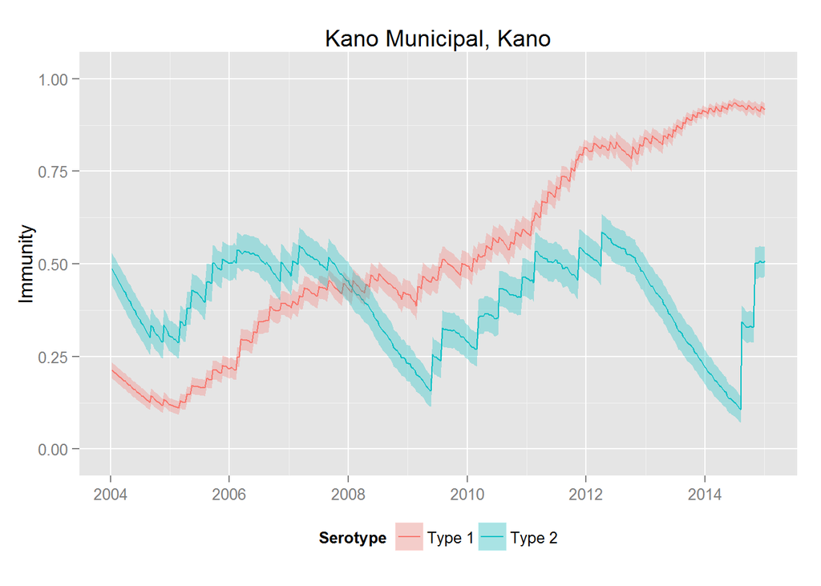

```r
tmp = simulateImmunization(campaigns=kano.camps, initial.doses = initial.doses, dist.index=1, n.samples=300,
                           end.date=as.Date("2014-12-31"), cov.results=cov.results, generate.initials=F)
tmp2 = simulateImmunization(campaigns=kano.camps, initial.doses = initial.doses, dist.index=1, serotype=2, time.step=10,
                            n.samples=300, end.date=as.Date("2014-12-31"), cov.results=cov.results, generate.initials=F)
tmp$Serotype = "Type 1"; tmp2$Serotype = "Type 2"; pltdf = rbind(tmp, tmp2)
ggplot(pltdf, aes(x=date, y=mean, group=Serotype)) + geom_line(aes(col=Serotype)) +
  geom_ribbon(aes(ymin=lower_ci, ymax=upper_ci, fill=Serotype), alpha=0.3) +
  scale_y_continuous(limit=c(-0.02,1.02)) + theme(legend.position="bottom") + labs(x=NULL,y="Immunity", title="Kano Municipal, Kano")
```

Or this (note IPV campaign in Sumaila in the end of 2014):

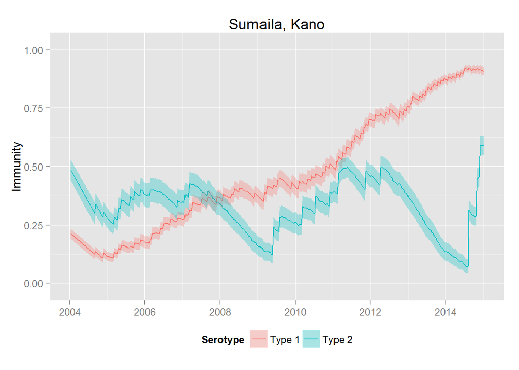

The following plot summarizes the heterogeneity in the coverage estimates by LGA:

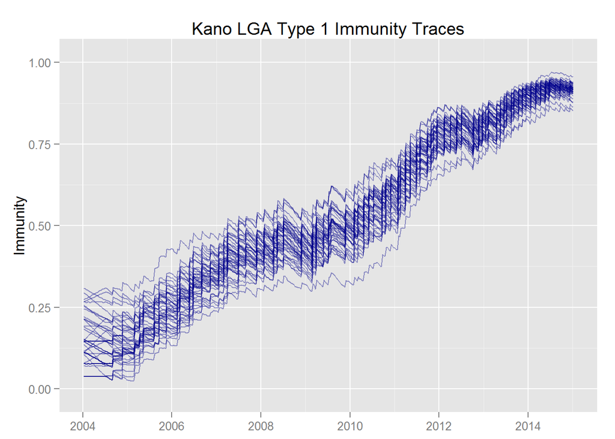

```r
out = lapply(1:44, function(x) {tmp = simulateImmunization(campaigns=kano.camps, dist.index=x,
                                                    n.samples=300, end.date=as.Date("2014-12-31"),cov.results=cov.results,
                                                    generate.initials=T, initials.random=T);tmp$index=x;tmp})
outb = do.call("rbind", out)
ggplot(outb, aes(x=date, y=mean, group=index)) + geom_line(col="darkblue",alpha=.4) +
  scale_y_continuous(limit=c(-0.02,1.02)) + labs(x=NULL,y="Immunity", title="Kano LGA Type 1 Immunity Traces")
```

We can do the same for type 2, this time the initial dose distributions are set equal for each LGA

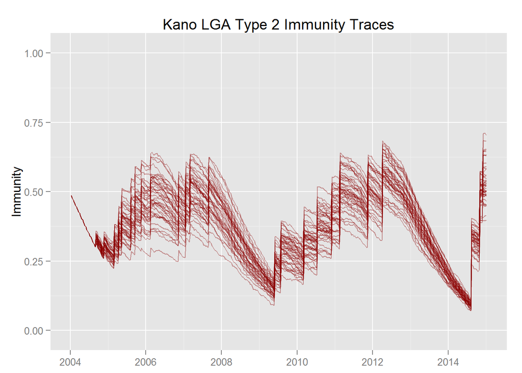

```r
initial.doses = data.frame(age_tranch=seq(0,4.5,.5), topv=rep(0:4,each=2),bopv=0,mopv1=0,mopv3=0,ipv=0)
out2 = lapply(1:44, function(x) {tmp = simulateImmunization(campaigns=kano.camps, dist.index=x, n.samples=300, initial.doses=initial.doses,
                                                            end.date=as.Date("2014-12-31"), serotype=2,cov.results=cov.results,
                                                           generate.initials=F, initials.random=F);tmp$index=x;tmp})
out2b = do.call("rbind", out2)
ggplot(out2b, aes(x=date, y=mean, group=index)) + geom_line(col="darkred",alpha=.4) +
  scale_y_continuous(limit=c(-0.02,1.02)) + labs(x=NULL,y="Immunity", title="Kano LGA Type 2 Immunity Traces")
```